# Lab-6

Tejaswini Sengaonkar

2023-10-02

```r
library(rpart)
library(randomForest)
library(parallel)
library(gbm)
library(caret)
```

1.In your own words, describe briefly the data and the practical problem that is associated with the data.

The dataset provides information on direct marketing campaigns conducted by a Portuguese banking institution. The dataset includes information such as age, job, marital status, and education level of the clients.It spans from May 2008 to November 2010, and seems to be ordered by date.There is an imbalance in the target variable, with significantly more instances of ‘no’ (not subscribing) compared to ‘yes’ (subscribing)

2. Grow an unpruned tree that fits the training data perfectly. (No need to plot it, as it may be quite large).

Consider pruning this tree using the cost-complexity criterion. Find the (absolute, not relative) deviance values of all the trees in the sequence of nested trees, along with the size of the trees (in terms of the number of leaf nodes). Explain why these values must be monotonically decreasing as the size of the tree increases?

```r
bank = read.csv("/course/data/bank/bank.csv", strings=TRUE)
train_data <- bank[1:1000,]
test_data <- bank[1001:nrow(bank),]

unpruned_tree <- rpart(y ~ ., data = train_data)
unpruned_tree
```

```
## n= 1000
##
## node), split, n, loss, yval, (yprob)
##       * denotes terminal node
##
##   1) root 1000 103 no (0.897000000 0.103000000)
##     2) duration< 473 862  49 no (0.943155452 0.056844548)
##       4) poutcome=failure,other 845  39 no (0.953846154 0.046153846)
##         8) month=apr,aug,feb,jan,jul,jun,mar,may,nov,sep 834  33 no (0.960431655 0.039568345)
##          16) duration< 213.5 559   3 no (0.994633274 0.005366726) *
##          17) duration>=213.5 275  30 no (0.890909091 0.109090909)
##            34) pdays< 358.5 268  25 no (0.906716418 0.093283582) *
##            35) pdays>=358.5 7   2 yes (0.285714286 0.714285714) *
##         9) month=oct 11   5 yes (0.454545455 0.545454545) *
##       5) poutcome=success 17   7 yes (0.411764706 0.588235294) *
##     3) duration>=473 138  54 no (0.608695652 0.391304348)
##       6) duration< 953.5 104  31 no (0.701923077 0.298076923)
##        12) poutcome=failure,other 96  25 no (0.739583333 0.260416667)
##          24) age>=44 30   3 no (0.900000000 0.100000000) *
##          25) age< 44 66  22 no (0.666666667 0.333333333)
##            50) day>=20.5 22   3 no (0.863636364 0.136363636) *
##            51) day< 20.5 44  19 no (0.568181818 0.431818182)
##             102) job=admin.,blue-collar,student,technician,unemployed 23   6 no (0.739130435 0.260869565) *
##             103) job=entrepreneur,housemaid,management,self-employed,services 21   8 yes (0.380952381 0.619047619)
##               206) month=apr,may,nov 9   3 no (0.666666667 0.333333333) *
##               207) month=aug,feb,jul,jun,oct 12   2 yes (0.166666667 0.833333333) *
##        13) poutcome=success 8   2 yes (0.250000000 0.750000000) *
##       7) duration>=953.5 34  11 yes (0.323529412 0.676470588)
##        14) month=may,nov,oct 14   6 no (0.571428571 0.428571429) *
##        15) month=aug,jan,jul,jun 20   3 yes (0.150000000 0.850000000) *
```

```r
deviance_values <- unpruned_tree$cptable[, "xerror"]
tree_sizes <- unpruned_tree$cptable[, "nsplit"]

result_df <- data.frame(Size = tree_sizes, Deviance = deviance_values)
print(result_df)
```

```
##   Size  Deviance
## 1    0 1.0000000
## 2    2 0.9708738
## 3    3 0.9805825
## 4    4 1.0388350
## 5    5 1.0679612
## 6    9 1.0679612
## 7   12 1.0679612
```

```r
(cp = unpruned_tree$cptable[which.min(unpruned_tree$cptable[,"xerror"]), 1])
```

```
## [1] 0.03883495
```

3. Consider pruning the unpruned tree obtained in Task 2, using the cost-complexity criterion.

Find both the training and test errors of all the nested trees in the sequence. Show both error curves versus the size of the tree in one graph.

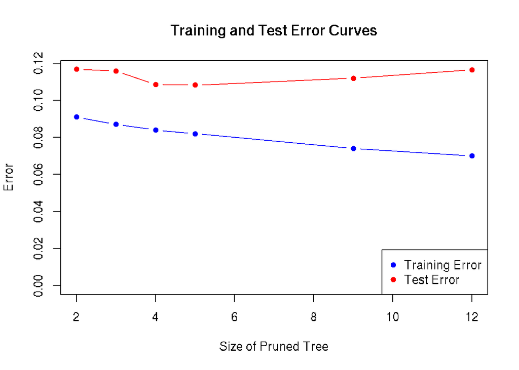

```r
train_errors <- numeric(7)
test_errors <- numeric(7)

for(i in 2:7) {
  rt <- prune(unpruned_tree, cp=unpruned_tree$cptable[i,1])
  train_predictions <- predict(rt, newdata = train_data, type = "class")
  test_predictions <- predict(rt, newdata = test_data, type = "class")

   train_errors[i] <- mean(train_predictions != train_data$y)
   test_errors[i] <- mean(test_predictions != test_data$y)
}
max_error <- max(c(max(train_errors), max(test_errors)))

plot(tree_sizes[2:7], train_errors[2:7], type = "b", col = "blue", pch = 16, xlab = "Size of Pruned Tree", ylab = "Error", main = "Training and Test Error Curves", ylim = c(0, max_error))
points(tree_sizes[2:7], test_errors[2:7], type = "b", col = "red", pch = 16)
legend("bottomright", legend = c("Training Error", "Test Error"), col = c("blue", "red"), pch = 16)
```

4. Consider pruning the tree using 10-fold cross-validation with 20 repetitions (in aid of parallel computing using 20 cores) for the purpose of minimising the deviance (the Gini index by default). You should make use of the CV results provided by rpart().

What are the training and test errors of the resulting pruned tree?

```r
set.seed(769)

num_reps <- 20
 num_cores <- 20
 cl <- makeCluster(num_cores)
 clusterEvalQ(cl, {
   library(rpart)
 })
```

[output not shown]

[output cut: 24 more lines]

[output not shown]

```r
clusterExport(cl, c("train_data", "unpruned_tree", "cp"))
 cv_prune <- function(seed) {
   set.seed(seed)
   cv_results <- rpart::prune(unpruned_tree,
                              data = train_data,
                              cp = cp,
                              minsplit = 2,
                              xval = 10)
   return(cv_results)
 }
 cv_results_list <- parLapply(cl, 1:num_reps, cv_prune)
 stopCluster(cl)
 combined_results <- do.call(rbind, lapply(cv_results_list, function(cv_result) cv_result$cptable))

 optimal_cp_index <- which.min(combined_results[, "xerror"])
 optimal_cp <- combined_results[optimal_cp_index, "CP"]


 pruned_tree <- prune(unpruned_tree, cp = optimal_cp)


 train_predictions <- predict(pruned_tree, newdata = train_data, type = "class")
 test_predictions <- predict(pruned_tree, newdata = test_data, type = "class")

 train_error <- mean(train_predictions != train_data$y)
 test_error <- mean(test_predictions != test_data$y)
```

[output not shown]

5.Produce a Bagging model for the training data with 500 trees (with nodesize=1) constructed. What are the three most important variables, in terms of the Gini index, according to Bagging? Compute both the training and test errors of this Bagging predictor. Is your test error similar to the OOB estimate? Does Bagging perform better than the pruned tree found in Task 4?

```r
bagging_model <- randomForest(y ~ ., data = train_data, ntree = 500, nodesize = 1)

# Print the importance of variables
print(importance(bagging_model))
```

```
##           MeanDecreaseGini
## age              13.782126
## job              15.225101
## marital           5.176073
## education         4.007302
## default           2.281591
## balance          17.930610
## housing           2.469677
## loan              1.169409
## contact           1.143375
## day              13.243631
## month            20.494883
## duration         56.331126
## campaign          6.955180
## pdays             7.868144
## previous          4.483359
## poutcome         10.740402
```

```r
# Predictions on training and test data
train_predictions_bagging <- predict(bagging_model, newdata = train_data)
test_predictions_bagging <- predict(bagging_model, newdata = test_data)

# Compute training and test errors for Bagging
train_error_bagging <- mean(train_predictions_bagging != train_data$y)
test_error_bagging <- mean(test_predictions_bagging != test_data$y)

# Print errors for Bagging
print(paste("Bagging Training Error:", train_error_bagging))
```

```
## [1] "Bagging Training Error: 0"
```

```r
print(paste("Bagging Test Error:", test_error_bagging))
```

```
## [1] "Bagging Test Error: 0.107923885259869"
```

```r
# Pruned tree
# Assuming "pruned_tree" is obtained from Task 4
pruned_test_predictions <- predict(pruned_tree, newdata = test_data)
pruned_test_error <- mean(pruned_test_predictions != test_data$y)

# Print pruned tree test error
print(paste("Pruned Tree Test Error:", pruned_test_error))
```

```
## [1] "Pruned Tree Test Error: 1"
```

6.Produce a Random Forest model with 500 trees (with nodesize=1) constructed.What are the three most important variables, in terms of accuracy, according to the Random Forest model? Compute both the training and test errors of this Random Forest predictor.Is your test error similar to the OOB estimate? Do you think the tweak used by Random Forest helps prediction here when compared with the Bagging predictor obtained in Task 5?

```r
# Create a Random Forest model with 500 trees
random_forest_model <- randomForest(y ~ ., data = train_data, ntree = 500, nodesize = 1)

# Print the importance of variables
print(importance(random_forest_model))
```

```
##           MeanDecreaseGini
## age              13.794191
## job              15.770599
## marital           4.839311
## education         3.874346
## default           2.421278
## balance          18.236791
## housing           2.400921
## loan              1.128274
## contact           1.007614
## day              13.606182
## month            20.196708
## duration         54.923399
## campaign          6.991886
## pdays             8.344422
## previous          4.402552
## poutcome         10.610820
```

```r
# Predictions on training and test data
train_predictions_rf <- predict(random_forest_model, newdata = train_data)
test_predictions_rf <- predict(random_forest_model, newdata = test_data)

# Compute training and test errors for Random Forest
train_error_rf <- mean(train_predictions_rf != train_data$y)
test_error_rf <- mean(test_predictions_rf != test_data$y)

# Print errors for Random Forest
print(paste("Random Forest Training Error:", train_error_rf))
```

```
## [1] "Random Forest Training Error: 0"
```

```r
print(paste("Random Forest Test Error:", test_error_rf))
```

```
## [1] "Random Forest Test Error: 0.107639875035501"
```

7. Further consider using nodesize=5,10,20, respectively, when building a Random Forest model with 500 trees constructed. Compute both the training and test errors of these Random Forest predictors. Do the training and test errors differ much for a different value of nodesize?

```r
# Set seed for reproducibility
set.seed(769)

# Create Random Forest models with different nodesize values
random_forest_model_5 <- randomForest(y ~ ., data = train_data, ntree = 500, nodesize = 5)
random_forest_model_10 <- randomForest(y ~ ., data = train_data, ntree = 500, nodesize = 10)
random_forest_model_20 <- randomForest(y ~ ., data = train_data, ntree = 500, nodesize = 20)

# Predictions on training and test data for each model
train_predictions_5 <- predict(random_forest_model_5, newdata = train_data)
test_predictions_5 <- predict(random_forest_model_5, newdata = test_data)

train_predictions_10 <- predict(random_forest_model_10, newdata = train_data)
test_predictions_10 <- predict(random_forest_model_10, newdata = test_data)

train_predictions_20 <- predict(random_forest_model_20, newdata = train_data)
test_predictions_20 <- predict(random_forest_model_20, newdata = test_data)

# Compute training and test errors for each model
train_error_5 <- mean(train_predictions_5 != train_data$y)
test_error_5 <- mean(test_predictions_5 != test_data$y)

train_error_10 <- mean(train_predictions_10 != train_data$y)
test_error_10 <- mean(test_predictions_10 != test_data$y)

train_error_20 <- mean(train_predictions_20 != train_data$y)
test_error_20 <- mean(test_predictions_20 != test_data$y)

# Print errors for each model
print("Nodesize = 5")
```

```
## [1] "Nodesize = 5"
```

```r
print(paste("Training Error:", train_error_5))
```

```
## [1] "Training Error: 0.018"
```

```r
print(paste("Test Error:", test_error_5))
```

```
## [1] "Test Error: 0.108491905708606"
```

```r
print("Nodesize = 10")
```

```
## [1] "Nodesize = 10"
```

```r
print(paste("Training Error:", train_error_10))
```

```
## [1] "Training Error: 0.032"
```

```r
print(paste("Test Error:", test_error_10))
```

```
## [1] "Test Error: 0.105935813689293"
```

```r
print("Nodesize = 20")
```

```
## [1] "Nodesize = 20"
```

```r
print(paste("Training Error:", train_error_20))
```

```
## [1] "Training Error: 0.062"
```

```r
print(paste("Test Error:", test_error_20))
```

```
## [1] "Test Error: 0.106787844362397"
```

8. Produce a Boosting model, using up to 500 trees, with the number of trees determined via 10-fold cross-validation.What are the three most important variables, according to Boosting?Compute both the training and test errors of this Boosting predictor.In terms of performance, how does this Boosting predictor compare with the other predictors obtained in Tasks 4, 5 and 6?

```r
train_data$y <- as.numeric(factor(train_data$y, levels = c("no", "yes"), labels = c(0, 1)))
test_data$y <- as.numeric(factor(test_data$y, levels = c("no", "yes"), labels = c(0, 1)))


boost_model <- gbm(y ~ ., data = train_data, distribution = "bernoulli",
                   n.trees = 500, interaction.depth = 4, cv.folds = 10)

# Print the summary of the Boosting model
summary(boost_model)

# Plot variable importance
plot(boost_model, n.trees = 500)

# Predictions on training and test data
train_predictions_boost <- predict(boost_model, newdata = train_data, n.trees = 500, type = "response")
test_predictions_boost <- predict(boost_model, newdata = test_data, n.trees = 500, type = "response")

# Convert predicted probabilities to binary predictions
train_predictions_boost_binary <- as.numeric(train_predictions_boost > 0.5)
test_predictions_boost_binary <- as.numeric(test_predictions_boost > 0.5)

# Compute training and test errors for Boosting
train_error_boost <- mean(train_predictions_boost_binary != train_data$y)
test_error_boost <- mean(test_predictions_boost_binary != test_data$y)

# Print errors for Boosting
print(paste("Boosting Training Error:", train_error_boost))
print(paste("Boosting Test Error:", test_error_boost))

# Pruned tree
pruned_test_predictions <- predict(pruned_tree, newdata = test_data)
pruned_test_error <- mean(pruned_test_predictions != test_data$y)

# Bagging
test_predictions_bagging <- predict(bagging_model, newdata = test_data)
test_error_bagging <- mean(test_predictions_bagging != test_data$y)

# Random Forest
test_predictions_rf <- predict(random_forest_model, newdata = test_data)
test_error_rf <- mean(test_predictions_rf != test_data$y)

# Print errors for other predictors
print(paste("Pruned Tree Test Error:", pruned_test_error))
print(paste("Bagging Test Error:", test_error_bagging))
print(paste("Random Forest Test Error:", test_error_rf))
```

[output not shown]

```r
train_data <- bank[1:1000,]
test_data <- bank[1001:nrow(bank),]

train_errors <- numeric(500)
test_errors <- numeric(500)

train_data$y <- as.numeric(factor(train_data$y, levels = c("no", "yes"), labels = c(0, 1)))
test_data$y <- as.numeric(factor(test_data$y, levels = c("no", "yes"), labels = c(0, 1)))

r <- gbm(y ~ . - y, data=train_data, distribution="bernoulli", n.trees=500,interaction.depth=3)

p = predict(r, test_data, type="response")
```

[output not shown]

```
## Using 500 trees...
```

Summary